# Machine Learning Project

Lachlan Glascott May 2020

## Introduction

One thing that people regularly do is quantify how much of a particular activity they do, but they rarely quantify how well they do it. In this project, your goal will be to use data from accelerometers on the belt, forearm, arm, and dumbell of 6 participants.

The goal of your project is to predict the manner in which they did the exercise. This is the “classe” variable in the training set. You may use any of the other variables to predict with.

## Preprocessing

First we remove the variables with NA values from both the training and testing sets. Similarly, the descriptive string variables also need to be removed in order to perform the analysis.

```r
non.na.vars <- training %>%
  summarise_each(funs(mean(is.na(.)))) %>%
  select_if(~any(. == 0)) %>%
  names()

training_clean <- training %>%
  select_at(non.na.vars) %>%
  select(-X1, -user_name, -raw_timestamp_part_1, -raw_timestamp_part_2, -cvtd_timestamp, -new_window, -num_window)

training_partition <- createDataPartition(y=training_clean$classe, p=0.75, list=FALSE)
training_set <- training_clean[training_partition, ]
test_set <- training_clean[-training_partition, ]
```

The provided training data was partitioned further into a training set (75% of data) and a testing set (essentially being used as a validation set). The chosen method was sampling without replacement to minimise the already significant computation required to run the models.

The selected models will be fitted using the training data and tested on the testing data set. The most accurate model will be used to make predictions on the testing set provided.

```r
training_partition <- createDataPartition(y=training_clean$classe, p=0.75, list=FALSE)
training_set <- training_clean[training_partition, ]
test_set <- training_clean[-training_partition, ]

dim(training_set); dim(test_set)
```

```
## [1] 14718    53
```

```
## [1] 4904   53
```

## Data Exploration

There are five classes in the dataset from A to E, each making up a reasonable proportion of the total outcomes.

```
## # A tibble: 5 x 2
##   classe count
##   <chr>  <int>
## 1 A       4185
## 2 B       2848
## 3 C       2567
## 4 D       2412
## 5 E       2706
```

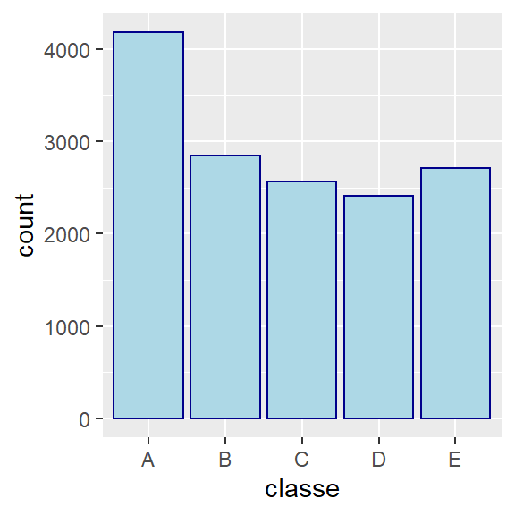

Since there are more than two classes we will use tree based approaches to fit the model and make classification predictions.

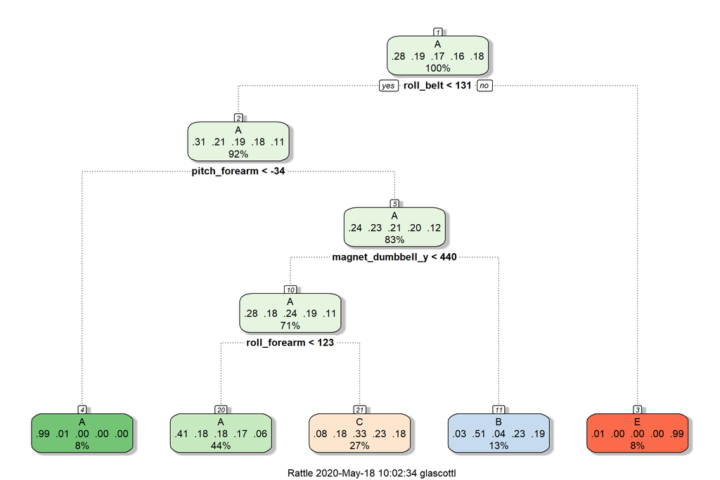

```r
model_tree <- train(classe ~ .,data=training_set, method="rpart")

fancyRpartPlot(model_tree$finalModel)
```

```r
pred_tree <- predict(model_tree, test_set)

confusionMatrix(pred_tree, as.factor(test_set$classe))
```

```
## Confusion Matrix and Statistics
##
##           Reference
## Prediction    A    B    C    D    E
##          A 1264  382  395  363  125
##          B   23  333   33  139  124
##          C  103  234  427  302  251
##          D    0    0    0    0    0
##          E    5    0    0    0  401
##
## Overall Statistics
##
##                Accuracy : 0.4945
##                  95% CI : (0.4804, 0.5086)
##     No Information Rate : 0.2845
##     P-Value [Acc > NIR] : < 2.2e-16
##
##                   Kappa : 0.3397
##
##  Mcnemar's Test P-Value : NA
##
## Statistics by Class:
##
##                      Class: A Class: B Class: C Class: D Class: E
## Sensitivity            0.9061   0.3509  0.49942   0.0000  0.44506
## Specificity            0.6395   0.9193  0.78019   1.0000  0.99875
## Pos Pred Value         0.4998   0.5107  0.32422      NaN  0.98768
## Neg Pred Value         0.9448   0.8551  0.88068   0.8361  0.88884
## Prevalence             0.2845   0.1935  0.17435   0.1639  0.18373
## Detection Rate         0.2577   0.0679  0.08707   0.0000  0.08177
## Detection Prevalence   0.5157   0.1330  0.26856   0.0000  0.08279
## Balanced Accuracy      0.7728   0.6351  0.63980   0.5000  0.72191
```

```r
model_rf <- train(classe ~ ., method = "rf", data=training_set)

pred_rf <- predict(model_rf, test_set)
```

```r
confusionMatrix(pred_rf, as.factor(test_set$classe))
```

```
## Confusion Matrix and Statistics
##
##           Reference
## Prediction    A    B    C    D    E
##          A 1393    2    0    0    0
##          B    2  946    8    0    1
##          C    0    1  847   15    1
##          D    0    0    0  789    0
##          E    0    0    0    0  899
##
## Overall Statistics
##
##                Accuracy : 0.9939
##                  95% CI : (0.9913, 0.9959)
##     No Information Rate : 0.2845
##     P-Value [Acc > NIR] : < 2.2e-16
##
##                   Kappa : 0.9923
##
##  Mcnemar's Test P-Value : NA
##
## Statistics by Class:
##
##                      Class: A Class: B Class: C Class: D Class: E
## Sensitivity            0.9986   0.9968   0.9906   0.9813   0.9978
## Specificity            0.9994   0.9972   0.9958   1.0000   1.0000
## Pos Pred Value         0.9986   0.9885   0.9803   1.0000   1.0000
## Neg Pred Value         0.9994   0.9992   0.9980   0.9964   0.9995
## Prevalence             0.2845   0.1935   0.1743   0.1639   0.1837
## Detection Rate         0.2841   0.1929   0.1727   0.1609   0.1833
## Detection Prevalence   0.2845   0.1951   0.1762   0.1609   0.1833
## Balanced Accuracy      0.9990   0.9970   0.9932   0.9907   0.9989
```

Because of the high accuracy we go ahead and make the final predcitons in the test set using the random forest model. The final predictions for the test set are shown below.

```r
predictfinal <- predict(model_rf, test)
predictfinal
```

```
##  [1] B A B A A E D B A A B C B A E E A B B B
## Levels: A B C D E
```